# AKSSF Temperature Data Summary

Document last updated 2022-03-24 16:31:36 by Rebecca Shaftel (rsshaftel@alaska.edu).

This report summarizes the new thermal sensitivity results with an interaction between air temperature and daylength. Tim redid the DFA comparing models with air temperature only, daylength only, air temperature + daylength, and air temperature x daylength (interaction). The model with the interaction term had the lowest AIC. These are single trend models using subset 1 (removed some Deshka sites).

# 1 New DFA results

Common trends across the four different models. There were four columns in the original data frame so I’m assuming that ‘NA.’ might be the interaction model. The trends are similar across the models and years except for the air temperature only model, which deviates in the fall in 2012, 2015, and 2019.

```r
load("DFA/output_17Mar22/DFAresults_GlobalDayLength_wInteraction_AllSubsets.Rdata")

md <- readRDS("data_preparation/final_data/md_2022-02-08.rds")
mod_dat <- readRDS("data_preparation/final_data/model_data2022-02-25.rds")

sp_dat <- mod_dat %>%
  select(SiteID, str_ord:log_precip) %>%
  distinct() %>%
  left_join(md %>% select(SiteID = Site, Waterbody_name))

ts_doy <- TempSens_Interaction_Subset1 %>%
  left_join(sp_dat) %>%
  filter(!is.na(region))

ts_site <- GlobalResults_DayLen_Subset1 %>%
  select(SiteID, Year, contains("Sens")) %>%
  pivot_longer(cols = contains(c("Sens"))) %>%
  distinct() %>%
  mutate(parameter = strsplit(name, "_") %>% sapply("[", 1),
         model = strsplit(name, "_") %>% sapply("[", 2),
         ts_type = case_when(grepl("Z", parameter) ~ "z-score",
                             TRUE ~ "raw"),
         covariate = gsub("Z", "", parameter))
```

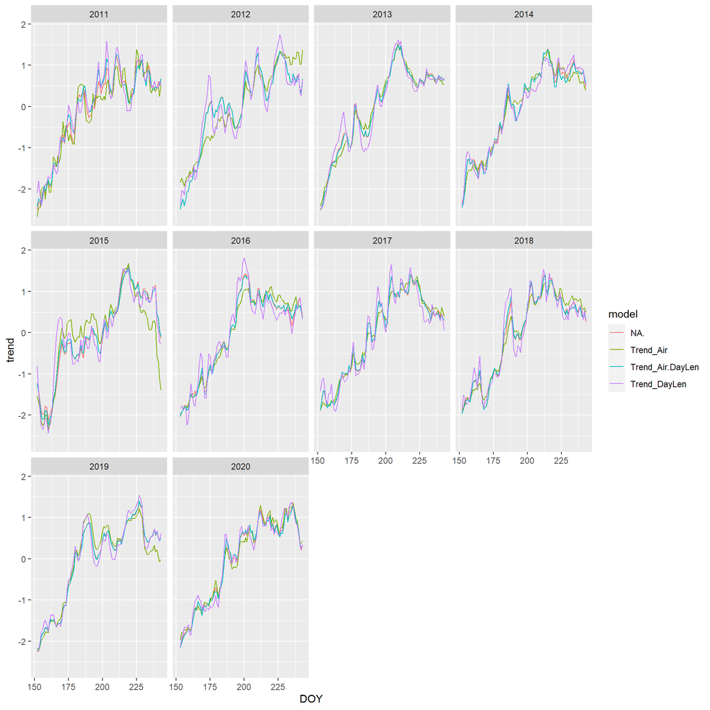

```r
GlobalTrends_DayLen_Subset1 %>%
  pivot_longer(cols = Trend_Air:NA., names_to = "model", values_to = "trend") %>%
  ggplot(aes(x = DOY, y = trend, color = model)) +
  geom_line() +
  facet_wrap(~Year)
```

Comparison of sensitivities using a mean TS for each site and year in interaction model. Using the mean values, there are not really any differences in the distributions of raw TS by adding the interaction term. (Note I don’t have the raw daylength sensitivities for the interaction model, which would also vary by day, but I don’t think we’re as interested in this term.)

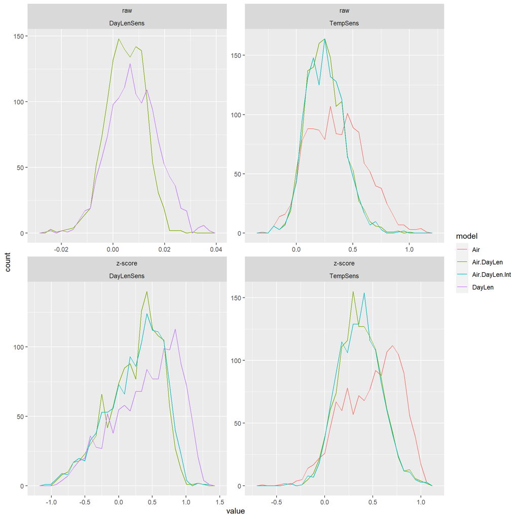

```r
ts_doy %>%
  group_by(SiteID, Year) %>%
  summarize(value = mean(TempSens_Int)) %>%
  mutate(parameter = "TempSens",
         model = "Air.DayLen.Int",
         ts_type = "raw",
         covariate = "TempSens") %>%
  bind_rows(ts_site) %>%
  ggplot(aes(x = value, color = model)) +
  geom_freqpoly() +
  facet_wrap(~ ts_type + covariate, scales = "free")
```

Using the maximum thermal sensitivities from each site and year in the interaction model leads to a shift in the distribution towards higher TS.

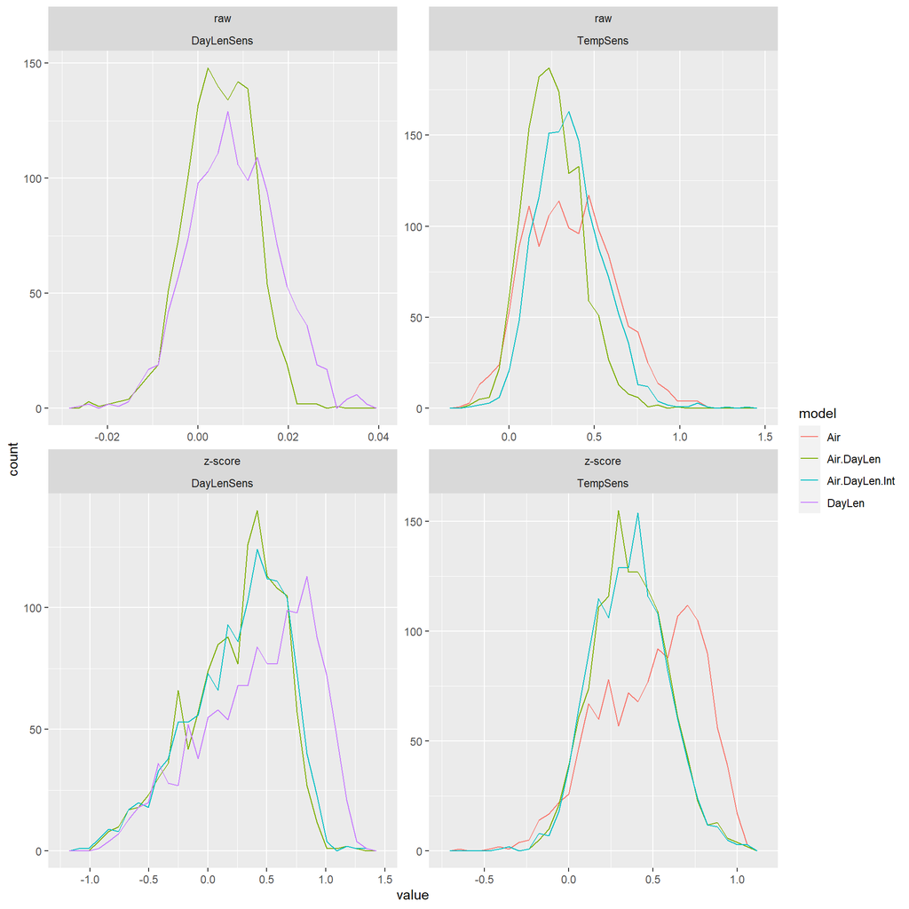

```r
ts_doy %>%
  group_by(SiteID, Year) %>%
  summarize(value = max(TempSens_Int)) %>%
  mutate(parameter = "TempSens",
         model = "Air.DayLen.Int",
         ts_type = "raw",
         covariate = "TempSens") %>%
  bind_rows(ts_site) %>%
  ggplot(aes(x = value, color = model)) +
  geom_freqpoly() +
  facet_wrap(~ ts_type + covariate, scales = "free")
```

Exploration of how TS changes by day in the interaction model, first plot is patterns by region and year.

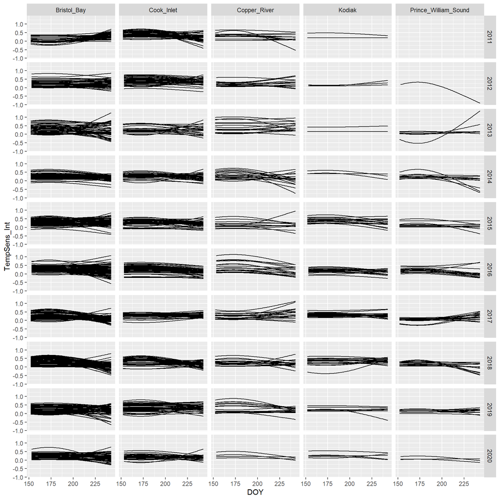

```r
ts_doy %>%
  filter(!is.na(region)) %>%
  # filter(Year %in% c(2012, 2015, 2019)) %>%
  ggplot(aes(x = DOY, y = TempSens_Int, group = SiteID)) +
  geom_line() +
  facet_grid(vars(Year), vars(region))
```

Exploration of some patterns for streams in Cook Inlet. Most common patterns are stable TS over the summer and decreasing TS in the fall, although some sites with increasing TS in the fall — low flows? 2016/2018 generally had higher than normal summer precipitation. Since rain is most common later in summer, possibly that explains the lower TS at the end of the summer.

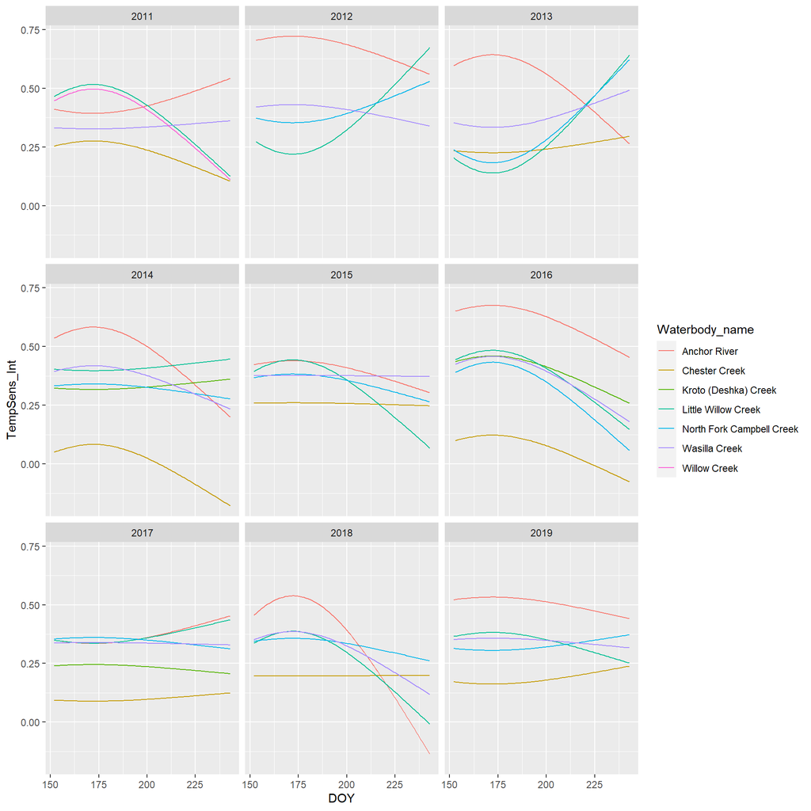

```r
ts_doy %>%
  filter(grepl("Anchor|Chester|Campbell|Wasilla|Willow", Waterbody_name) | Waterbody_name == "Kroto (Deshka) Creek") %>%
  ggplot(aes(x = DOY, y = TempSens_Int, color = Waterbody_name)) +
  geom_line() +
  facet_wrap(~Year)
```

Can also explore patterns of changing sensitivities depending on site type. Sites with > 5% glacier cover. No real patterns here, very different across sites and years, could partially be due to different sites in different years.

```r
ts_doy %>%
  filter(wtd_glacier_per > 5) %>%
  mutate(Glacier_cover = round(wtd_glacier_per, 1)) %>%
  distinct(SiteID, Waterbody_name, Glacier_cover) %>%
  arrange(desc(Glacier_cover)) %>%
  kable()
```

| SiteID | Waterbody_name | Glacier_cover |
| --- | --- | --- |
| usgs_15236900 | WOLVERINE C NR LAWING AK | 69.5 |
| USFS_Pigot Bay Spawn Channel | Pigot Bay Channel | 46.8 |
| USFS_Rude River SC | Rude River | 29.5 |
| nps_LACL_tlikr_stream_water | Tlikikila River | 27.6 |
| usgs_15272380 | TWENTYMILE R BL GLACIER R NR PORTAGE AK | 26.6 |
| usgs_15291000 | SUSITNA R NR DENALI AK | 22.8 |
| usgs_15239070 | BRADLEY R NR TIDEWATER NR HOMER AK | 20.3 |
| usgs_15292400 | CHULITNA R NR TALKEETNA AK | 19.7 |
| usgs_15238986 | BATTLE C 1.0 MI AB MOUTH NR HOMER AK | 14.3 |
| usgs_15294345 | YENTNA R NR SUSITNA STATION AK | 13.7 |
| USFS_Power Creek | Power Creek | 12.1 |
| usgs_15284000 | MATANUSKA R AT PALMER AK | 10.8 |
| usgs_15266300 | KENAI R AT SOLDOTNA AK | 10.2 |
| usgs_15294350 | SUSITNA R AT SUSITNA STATION AK | 8.8 |
| usgs_15292780 | SUSITNA R AT SUNSHINE AK | 7.7 |
| USFS_Salmon Creek | Salmon Creek | 7.3 |
| BM8 | NA | 7.2 |
| BM6 | NA | 6.5 |
| KWF2 | NA | 6.5 |
| BM7 | NA | 6.5 |
| USFS_Center Creek | Center Creek | 6.2 |
| fws_Newhalen River | Newhalen River | 6.0 |
| NPS_Newhalen_River | Newhalen River | 6.0 |
| USFS_Bench Creek | Bench Creek | 5.8 |
| kdk_bigcr01 | Big Creek | 5.8 |
| USFS_Ibeck Creek-Lower Side Channel | NA | 5.5 |
| USFS_Ibeck Creek-Low | Ibeck Creek | 5.5 |
| usgs_15291700 | SUSITNA R AB TSUSENA C NR CHULITNA AK | 5.1 |
| usgs_15300320 | CHINKELYES C BL SUMMIT LK NR PEDRO BAY AK | 5.0 |

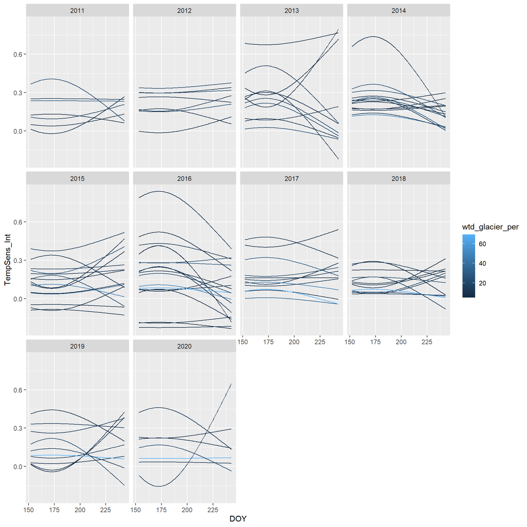

```r
ts_doy %>%
  filter(wtd_glacier_per > 5) %>%
  ggplot(aes(x = DOY, y = TempSens_Int, group = SiteID, color = wtd_glacier_per)) +
  geom_line() +
  facet_wrap(~Year)
```

Sites with mean watershed slope > 20% (top quartile of sites) and < 7% (bottom quartile of sites). The y axes are fixed so they are generally comparable. Interesting pattern in 2018 in the flat watersheds that matches the Cook Inlet sites.

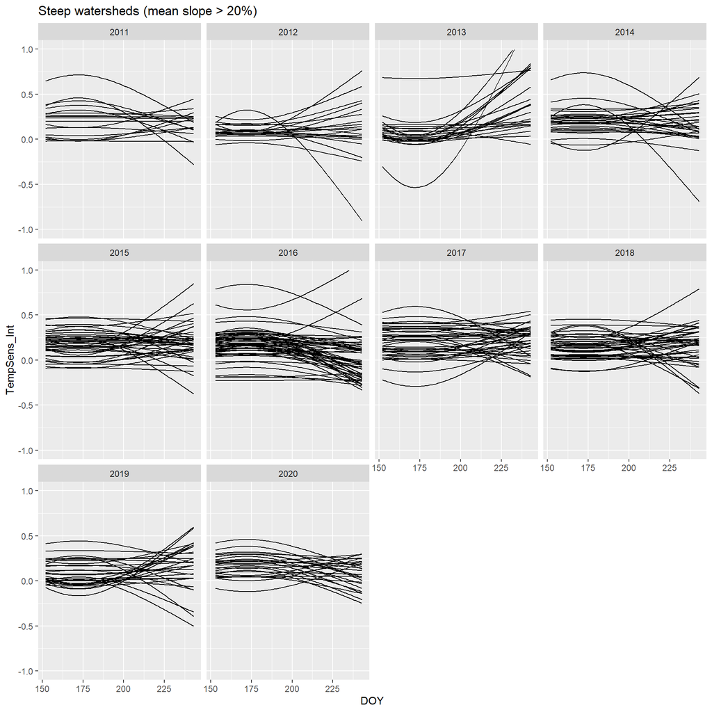

```r
# sens_doy %>% summary()

ts_doy %>%
  filter(wtd_slope_MEAN > 20) %>%
  ggplot(aes(x = DOY, y = TempSens_Int, group = SiteID)) +
  geom_line() +
  scale_y_continuous(limits = c(-1, 1)) +
  facet_wrap(~Year) +
  labs(title = "Steep watersheds (mean slope > 20%)")
```

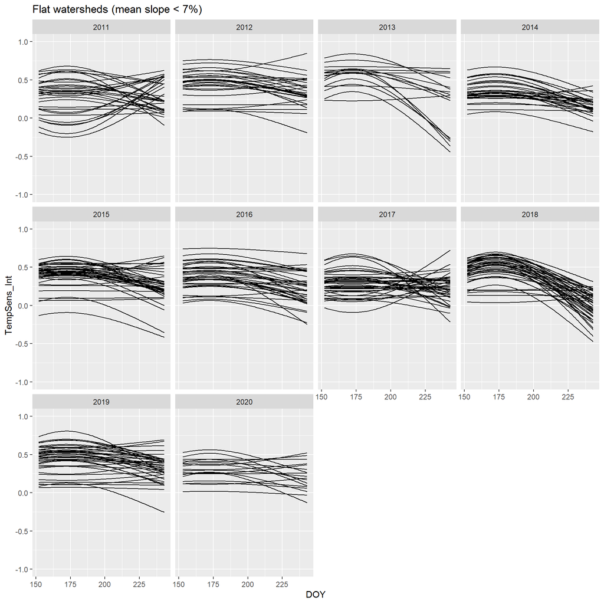

```r
ts_doy %>%
  filter(wtd_slope_MEAN < 7) %>%
  ggplot(aes(x = DOY, y = TempSens_Int, group = SiteID)) +
  geom_line() +
  scale_y_continuous(limits = c(-1, 1)) +
  facet_wrap(~Year) +
  labs(title = "Flat watersheds (mean slope < 7%)")
```

Exploration of how covariates relate to Thermal Sensitivities from interaction model.

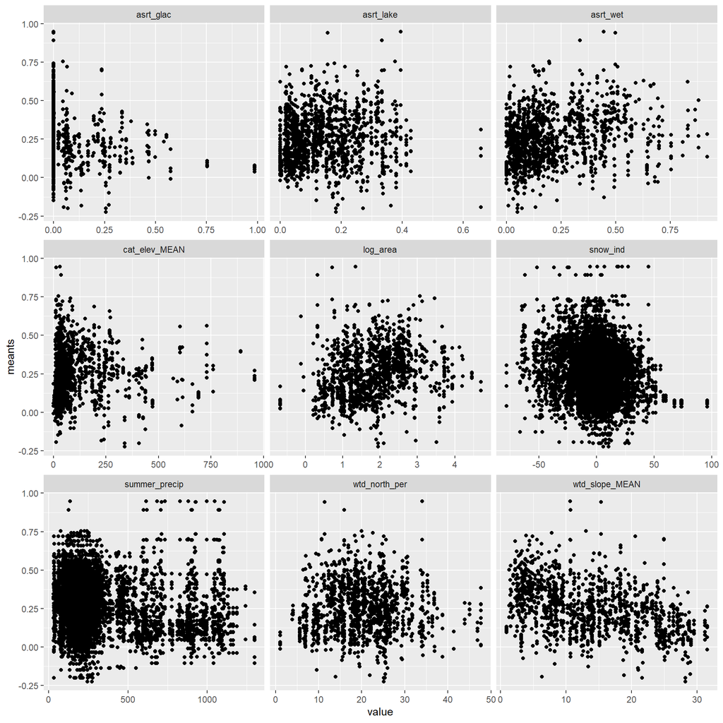

```r
ts_doy %>%
  group_by(SiteID, Year, wtd_slope_MEAN, asrt_glac, log_area,
         snow_ind, cat_elev_MEAN, asrt_lake, asrt_wet, wtd_north_per, summer_precip) %>%
  summarize(meants = mean(TempSens_Int),
            maxts = max(TempSens_Int)) %>%
  pivot_longer(cols = wtd_slope_MEAN:summer_precip, names_to = "vars", values_to = "value") %>%
  ggplot(aes(x = value, y = meants)) +
  geom_point() +
  facet_wrap(~vars, scales = "free_x") +
  labs("Mean summer thermal sensitivity")
```

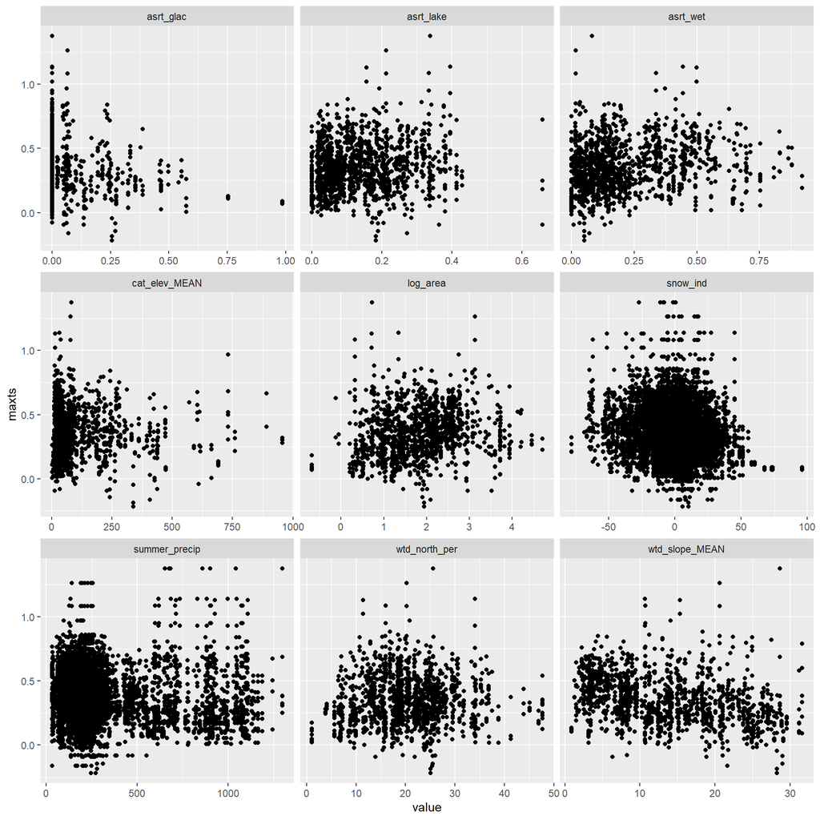

```r
ts_doy %>%
  group_by(SiteID, Year, wtd_slope_MEAN, asrt_glac, log_area,
         snow_ind, cat_elev_MEAN, asrt_lake, asrt_wet, wtd_north_per, summer_precip) %>%
  summarize(meants = mean(TempSens_Int),
            maxts = max(TempSens_Int)) %>%
  pivot_longer(cols = wtd_slope_MEAN:summer_precip, names_to = "vars", values_to = "value") %>%
  ggplot(aes(x = value, y = maxts)) +
  geom_point() +
  facet_wrap(~vars, scales = "free_x") +
  labs("Max summer thermal sensitivity")
```